# Learning-rate, training-horizon and subset sensitivity at 100 labelled images

**Stage 3 scientific report.** This notebook compares fixed learning rates for random and ImageNet initialization, tests a longer horizon and one predeclared learning-rate drop, and repeats the selected common recipe on a second saved training subset. All results use the same northern validation region and remain exploratory validation evidence; the geographically locked test region remains untouched.

## 1. Research question and fixed comparison

The Stage 2 pilot found validation IoU 0.813 for random initialization and 0.862 for ImageNet initialization at 100 training images and learning rate `3e-4`. We ask whether either initialization is sensitive to learning rate, whether random initialization benefits from a different rate, and whether the pretraining advantage remains at matched rates.

The approved candidates are `1e-4`, `3e-4` and `1e-3`. The two `3e-4` runs are the verified Stage 2 references; the other four models start fresh. All six configurations use the same Seed 17 subset, model seed, data order, D4 augmentation sequence, architecture, normalization, objective, weight decay, BatchNorm policy and 2,000-update horizon. The 259 test images remain excluded from training, selection, threshold analysis and examples.

### Selection and interpretation

The primary metric remains equally weighted mean per-image validation intersection over union (IoU) at probability threshold 0.5. Each run selects its highest trained validation IoU, with the earlier step winning ties; step 0 is diagnostic only. We report both best and final-step IoU because a low learning rate may still be improving at the fixed horizon. Comparisons at matched learning rates are primary. Selecting the best observed rate separately for each initialization uses the same validation data and is therefore explicitly exploratory.

```python
from pathlib import Path

import pandas as pd
from IPython.display import Image, display

ROOT = Path.cwd()
RESULTS = pd.read_csv(ROOT / 'reports/optimization_learning_rate_results.csv')
THRESHOLDS = pd.read_csv(ROOT / 'reports/optimization_threshold_results.csv')
```

## 2. Selected-checkpoint results

The table includes the six configurations, their selected validation metrics, final-step IoU and measured runtime. Average precision (AP) is averaged over the 288 validation images containing roof pixels; the empty reference is excluded only from AP.

```python
columns = {
    'initialization': 'initialization', 'learning_rate': 'learning rate',
    'best_validation_iou': 'best IoU', 'last_validation_iou': 'last IoU',
    'validation_dice': 'Dice', 'validation_ap': 'AP',
    'validation_ap_images': 'AP images', 'best_step': 'best step',
    'total_minutes': 'minutes',
}
display(RESULTS[list(columns)].rename(columns=columns).style.format({
    'learning rate': '{:.0e}', 'best IoU': '{:.3f}', 'last IoU': '{:.3f}',
    'Dice': '{:.3f}', 'AP': '{:.3f}', 'minutes': '{:.1f}',
}).hide(axis='index'))
```

| initialization | learning rate | best IoU | last IoU | Dice | AP | AP images | best step | minutes |
| --- | --- | --- | --- | --- | --- | --- | --- | --- |
| imagenet | 1e-04 | 0.857 | 0.857 | 0.918 | 0.945 | 288 | 2000 | 12.9 |
| imagenet | 3e-04 | 0.862 | 0.858 | 0.923 | 0.960 | 288 | 1400 | 13.2 |
| imagenet | 1e-03 | 0.865 | 0.865 | 0.924 | 0.970 | 288 | 2000 | 13.1 |
| random | 1e-04 | 0.793 | 0.793 | 0.879 | 0.943 | 288 | 2000 | 13.4 |
| random | 3e-04 | 0.813 | 0.807 | 0.892 | 0.957 | 288 | 1700 | 13.1 |
| random | 1e-03 | 0.817 | 0.817 | 0.894 | 0.959 | 288 | 1800 | 13.2 |

At matched learning rates, ImageNet initialization has the higher selected IoU in all three comparisons. Random initialization improves from 0.793 at `1e-4` to 0.813 at `3e-4` and 0.817 at `1e-3`. ImageNet improves from 0.857 to 0.862 and 0.865. The best observed rate is therefore `1e-3` for both initializations, but this conclusion is selected on the same validation region and the margins over `3e-4` are small: 0.004 for random and 0.003 for ImageNet.

The four new runs required 42.2 minutes of optimization and 52.7 minutes including evaluation on MPS, closely matching the 53-minute estimate. All AP values average the same 288 non-empty validation images.

## 3. Learning trajectories and fixed horizon

The upper panels show validation IoU at every predeclared evaluation. The lower panels show the augmented training objective over the preceding 100 updates. The objective is useful for optimization diagnostics but is not directly comparable with unaugmented validation loss.

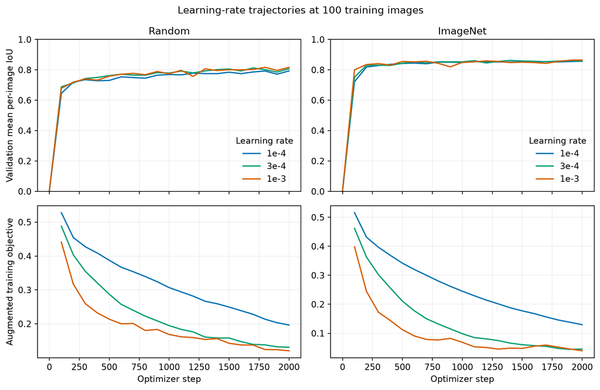

```python
display(Image(filename=ROOT / 'reports/figures/optimization_learning_rate_curves.png'))
```

Both `1e-4` runs select the final step and their training objectives remain substantially above those at larger rates. Their lower 2,000-step scores therefore indicate underoptimization at this horizon rather than a demonstrated lower attainable performance. The `1e-3` random run selects step 1,800 and ends at nearly the same IoU; the ImageNet run is more variable but reaches its best result at step 2,000. None of these observations establishes convergence beyond the fixed horizon.

## 4. Matched-rate initialization differences

Within every rate, the two initializations use the same subset, data order, D4 codes and initial decoder. Positive values below mean that ImageNet initialization scores higher than random initialization at the corresponding selected checkpoints.

| learning_rate | IoU | Dice | AP |
| --- | --- | --- | --- |
| 0.000100 | +0.064 | +0.039 | +0.002 |
| 0.000300 | +0.050 | +0.031 | +0.003 |
| 0.001000 | +0.048 | +0.029 | +0.011 |

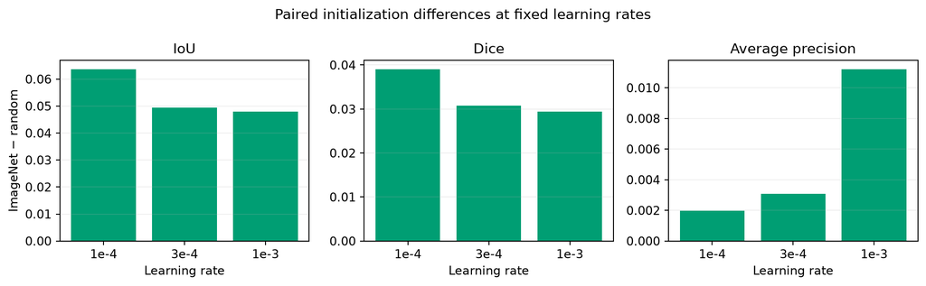

```python
paired = RESULTS.pivot(index='learning_rate', columns='initialization',
                       values=['best_validation_iou', 'validation_dice', 'validation_ap'])
differences = pd.DataFrame({
    name: paired[(column, 'imagenet')] - paired[(column, 'random')]
    for name, column in {'IoU': 'best_validation_iou', 'Dice': 'validation_dice',
                         'AP': 'validation_ap'}.items()
})
display(differences.style.format('{:+.3f}'))
display(Image(filename=ROOT / 'reports/figures/optimization_paired_differences.png'))
```

The ImageNet-minus-random IoU differences are +0.064 at `1e-4`, +0.050 at `3e-4` and +0.048 at `1e-3`. The pretraining advantage therefore remains positive throughout the fixed search range and is not removed by giving random initialization the same higher rate. Dice shows the same ordering. AP differences are smaller at `1e-4` and `3e-4`, illustrating that similar pixel ranking does not imply the same thresholded overlap.

## 5. Diagnostic threshold sensitivity of the references

For exactly the two stored `3e-4` reference checkpoints, we recompute validation IoU at thresholds 0.1 through 0.9. Aggregation and empty-mask rules are unchanged. This diagnostic does not alter the primary threshold, checkpoint selection or learning-rate selection. A favourable validation threshold would not be an independently confirmed result, and similar AP does not establish equal segmentation quality or probability calibration.

| initialization threshold | imagenet | random |
| --- | --- | --- |
| 0.100000 | 0.853 | 0.783 |
| 0.200000 | 0.859 | 0.805 |
| 0.300000 | 0.861 | 0.811 |
| 0.400000 | 0.862 | 0.812 |
| 0.500000 | 0.862 | 0.813 |
| 0.600000 | 0.861 | 0.810 |
| 0.700000 | 0.858 | 0.806 |
| 0.800000 | 0.849 | 0.795 |
| 0.900000 | 0.813 | 0.754 |

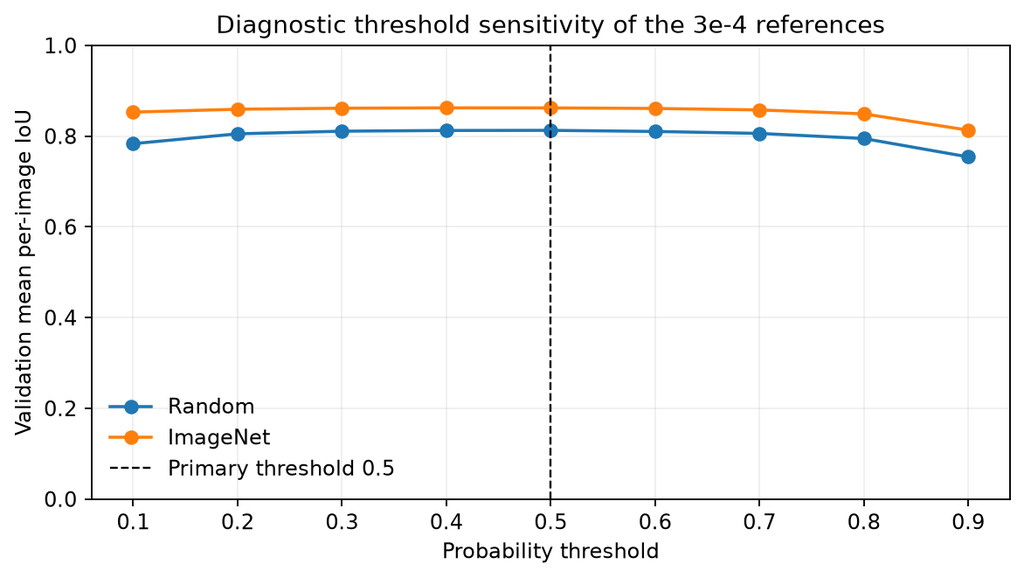

```python
threshold_table = THRESHOLDS.pivot(index='threshold', columns='initialization', values='mean_iou')
display(threshold_table.style.format('{:.3f}'))
display(Image(filename=ROOT / 'reports/figures/optimization_threshold_curves.png'))
```

Random initialization reaches its maximum measured IoU at the primary threshold 0.5. ImageNet reaches 0.8623 at 0.4 versus 0.8622 at 0.5, a negligible validation-selected difference. Across all nine thresholds, ImageNet remains ahead by 0.050–0.070 IoU. The reference gap is therefore not explained by an unfortunate threshold choice for the random model, although this coarse diagnostic is not a calibration study.

## 6. Common validation cases

The examples compare each initialization at its best observed learning rate. Cases are selected from validation metrics to show a shared failure, the largest disagreement, a shared success and the known empty target; criteria may coincide. Error maps use green for true positives, orange for false positives and blue for false negatives. No test image or prediction is used.

```
Selected validation IDs: 39, 1252, 147
```

[figure not shown]

```python
selected_ids = (ROOT / 'reports/optimization_example_ids.txt').read_text().splitlines()
print('Selected validation IDs:', ', '.join(selected_ids))
display(Image(filename=ROOT / 'reports/figures/optimization_examples.png'))
```

The four criteria yield three unique IDs because the empty target, ID 39, is also the lowest paired-IoU case; both models produce false positives and score IoU 0. ID 1252 is the largest disagreement between the two best-rate models: the ImageNet model recovers substantially more of the central roof. ID 147 is a shared high-IoU case. These validation-selected examples explain error structure but do not constitute independent evidence.

## 7. Does extending training change the learning-rate conclusion?

Both historical `1e-4` runs selected the final available checkpoint at 2,000 updates, so their lower scores could reflect insufficient optimization time. We therefore ran exactly four fresh configurations: random and ImageNet initialization at constant learning rates `1e-4` and `1e-3`, each for 4,000 updates. Evaluation was fixed at step 0 and every 100 updates. The split, 100-image subset, D4 schedule seeds, architecture, loss, batch size, AdamW parameter groups and threshold remained unchanged.

The four runs start from the original random or ImageNet state with a fresh decoder; no trained weights or optimizer states are resumed. Their first 2,000 sample IDs and D4 transforms have the same verified schedule hash as the earlier runs. Values through 2,000 and through 4,000 below are two views of each new curve, avoiding a comparison between independently trained trajectories.

```python
HORIZON_RESULTS = pd.read_csv(
    ROOT / 'reports/optimization_training_horizon_results.csv'
)
horizon_columns = {
    'initialization': 'initialization', 'learning_rate': 'learning rate',
    'best_step_first_2000': 'best step ≤2k', 'best_iou_first_2000': 'best IoU ≤2k',
    'best_step_all_4000': 'best step ≤4k', 'best_iou_all_4000': 'best IoU ≤4k',
    'iou_step_2000': 'IoU at 2k', 'iou_step_4000': 'IoU at 4k',
    'selected_validation_dice': 'Dice', 'selected_validation_ap': 'AP',
    'selected_training_iou': 'train IoU', 'updates': 'updates',
    'data_passages': 'data passages', 'total_minutes': 'total min',
}
display(HORIZON_RESULTS[list(horizon_columns)].rename(columns=horizon_columns).style.format({
    'learning rate': '{:.0e}', 'best IoU ≤2k': '{:.3f}', 'best IoU ≤4k': '{:.3f}',
    'IoU at 2k': '{:.3f}', 'IoU at 4k': '{:.3f}', 'Dice': '{:.3f}', 'AP': '{:.3f}',
    'train IoU': '{:.3f}', 'data passages': '{:.0f}', 'total min': '{:.1f}',
}))
```

|  | initialization | learning rate | best step ≤2k | best IoU ≤2k | best step ≤4k | best IoU ≤4k | IoU at 2k | IoU at 4k | Dice | AP | train IoU | updates | data passages | total min |
| --- | --- | --- | --- | --- | --- | --- | --- | --- | --- | --- | --- | --- | --- | --- |
| 0 | imagenet | 1e-04 | 2000 | 0.857 | 3400 | 0.863 | 0.857 | 0.861 | 0.922 | 0.955 | 0.964 | 4000 | 160 | 25.8 |
| 1 | imagenet | 1e-03 | 2000 | 0.865 | 2000 | 0.865 | 0.865 | 0.860 | 0.924 | 0.970 | 0.942 | 4000 | 160 | 25.3 |
| 2 | random | 1e-04 | 2000 | 0.793 | 3700 | 0.811 | 0.793 | 0.798 | 0.889 | 0.947 | 0.894 | 4000 | 160 | 25.3 |
| 3 | random | 1e-03 | 1800 | 0.817 | 3900 | 0.831 | 0.817 | 0.806 | 0.904 | 0.964 | 0.897 | 4000 | 160 | 36.6 |

The longer horizon changes the random-initialization result more than the ImageNet result. Random `1e-4` improves from a best IoU of 0.793 within 2,000 updates to 0.811 at step 3,700; random `1e-3` improves from 0.817 to 0.831 at step 3,900. ImageNet `1e-4` improves more modestly, from 0.857 to 0.863 at step 3,400. ImageNet `1e-3` does not improve on its 0.865 value at step 2,000 and remains the highest observed configuration.

At the selected long-horizon checkpoints, ImageNet remains ahead by 0.052 IoU at `1e-4` and 0.034 at `1e-3`. Thus additional updates narrow but do not remove the observed pretraining advantage. The comparison is still exploratory validation selection on one subset and one model seed.

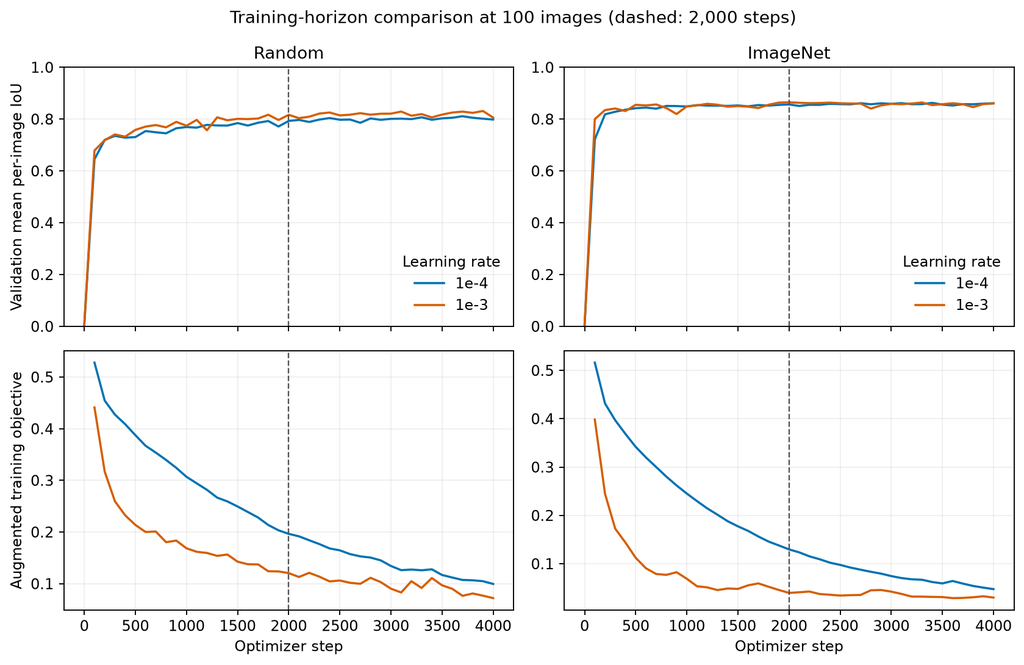

```python
display(Image(filename=ROOT / 'reports/figures/optimization_training_horizon_curves.png'))
```

The dashed line marks the earlier 2,000-update limit. Both random curves reach higher maxima after it, but their step-4,000 endpoints (0.798 and 0.806) are below their selected maxima. In the second half, random `1e-4` has mean IoU 0.800 (standard deviation 0.006) and random `1e-3` has 0.819 (0.008). The latter therefore retains the better sustained level despite visible checkpoint-to-checkpoint variation.

The two ImageNet curves have almost identical second-half means of 0.858. ImageNet `1e-4` rises slightly beyond its 2,000-update value, whereas `1e-3` remains near but mostly below its step-2,000 maximum. The falling training objectives and high matched training IoUs show continuing fit to the training subset, while validation plateaus and oscillates. This supports neither proven convergence nor a claim of monotonic overfitting. Forty trained validation checks also give the 4,000-step maximum more selection opportunities than the earlier horizon, so the endpoints and second-half distributions matter alongside the maxima.

## 8. Common validation cases under the extended horizon

For a compact qualitative check, each initialization uses its highest-IoU long-run configuration, `1e-3` in both cases. The cases are selected only from validation metrics to represent the lowest paired IoU, largest initialization disagreement, highest paired IoU and an empty reference. Duplicate criteria leave three unique images. Green denotes true-positive roof pixels, orange false positives and blue false negatives.

```
Selected validation IDs: 39, 1253, 147
```

[figure not shown]

```python
horizon_ids = (
    ROOT / 'reports/optimization_training_horizon_example_ids.txt'
).read_text().splitlines()
print('Selected validation IDs:', ', '.join(horizon_ids))
display(Image(filename=ROOT / 'reports/figures/optimization_training_horizon_examples.png'))
```

ID 39 has an empty reference and both models produce false-positive roof pixels, yielding IoU 0 under the predeclared empty-mask rule. ID 1253 is the largest disagreement: the ImageNet model covers the reference roof much more completely, whereas the random model leaves a larger false-negative region. ID 147 is a shared high-IoU case; both models closely follow the annotated roof. These examples illustrate the selected models but do not estimate geographic test performance.

## 9. Are the late constant-rate trajectories still changing?

A selected maximum alone does not show convergence: repeated measurements on one validation set can fluctuate while the underlying trajectory still rises or falls. We therefore examine the 20 predeclared validation measurements from steps 2,100 through 4,000 for each constant-rate long run. For validation IoU and validation loss separately, an ordinary least-squares line provides a descriptive trend per 1,000 updates. The residual standard deviation (SD) describes scatter around that line; it is **not** a confidence interval because adjacent checkpoints share the same training trajectory and validation images.

We also compare the means of steps 2,100–3,000 and 3,100–4,000. Rolling trends use the same definition in every run: ten consecutive validation measurements, equivalent to 1,000 updates, shifted forward by one measurement. The earlier full-curve SD reported in the horizon analysis was the SD of validation IoU, not loss, and it mixed systematic trend with local variation. A gain smaller than one SD is therefore not a convergence rule.

```python
LATE_TRENDS = pd.read_csv(ROOT / 'reports/optimization_late_training_trends.csv')
late_columns = {
    'initialization': 'initialization', 'learning_rate': 'learning rate',
    'iou_trend_per_1000': 'IoU trend / 1,000', 'iou_residual_sd': 'IoU residual SD',
    'iou_mean_2100_3000': 'IoU mean 2,100–3,000',
    'iou_mean_3100_4000': 'IoU mean 3,100–4,000',
    'loss_trend_per_1000': 'loss trend / 1,000', 'loss_residual_sd': 'loss residual SD',
}
display(LATE_TRENDS[list(late_columns)].rename(columns=late_columns).style.format({
    'learning rate': '{:.0e}', 'IoU trend / 1,000': '{:+.4f}',
    'IoU residual SD': '{:.4f}', 'IoU mean 2,100–3,000': '{:.3f}',
    'IoU mean 3,100–4,000': '{:.3f}', 'loss trend / 1,000': '{:+.4f}',
    'loss residual SD': '{:.4f}',
}))
```

|  | initialization | learning rate | IoU trend / 1,000 | IoU residual SD | IoU mean 2,100–3,000 | IoU mean 3,100–4,000 | loss trend / 1,000 | loss residual SD |
| --- | --- | --- | --- | --- | --- | --- | --- | --- |
| 0 | imagenet | 1e-04 | +0.0017 | 0.0028 | 0.857 | 0.858 | -0.0216 | 0.0062 |
| 1 | imagenet | 1e-03 | -0.0027 | 0.0055 | 0.858 | 0.858 | +0.0100 | 0.0043 |
| 2 | random | 1e-04 | +0.0051 | 0.0048 | 0.797 | 0.803 | -0.0210 | 0.0045 |
| 3 | random | 1e-03 | +0.0038 | 0.0075 | 0.817 | 0.820 | -0.0026 | 0.0064 |

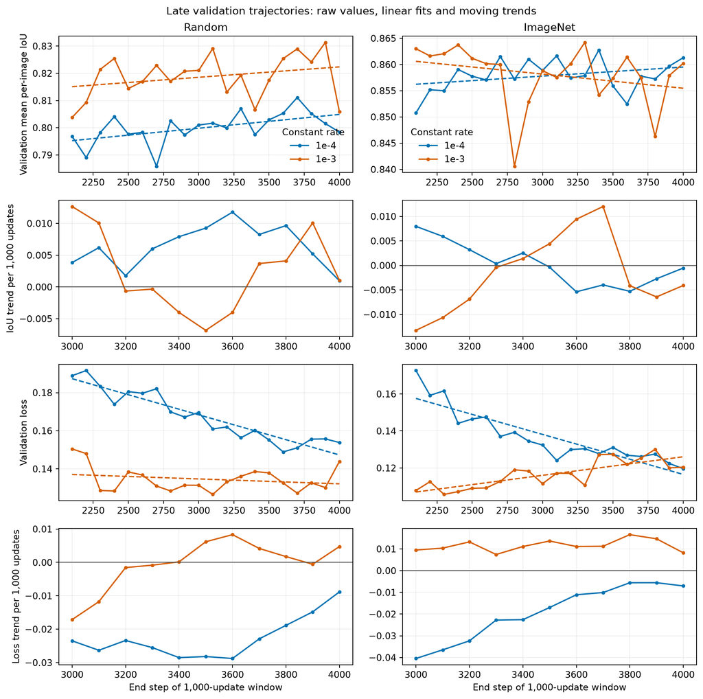

```python
display(Image(filename=ROOT / 'reports/figures/optimization_late_training_trends.png'))
```

For ImageNet initialization, constant `1e-4` changes slowly in IoU (+0.0017) while loss continues to fall. Constant `1e-3` has a negative late IoU trend (−0.0027) and rising validation loss (+0.0100), despite intermittent high-IoU checkpoints. The recorded augmented training objective does not reverse in the same way, which is compatible with a validation deterioration or calibration change. It is not a like-for-like train/validation comparison: the training value is measured in training mode over augmented mini-batches, whereas validation loss uses deterministic images and evaluation mode.

## 10. Predeclared fixed learning-rate drop

The late behavior motivates one limited schedule test rather than a wider search. Two fresh runs use `1e-3` for optimizer steps 1–2,000 and `1e-4` for steps 2,001–4,000, once with random initialization and once with the original ImageNet encoder weights. The decoder is freshly initialized in both cases. Subset, batch order, D4 augmentation, loss, weight decay, validation schedule and all other settings match the constant-`1e-3` references. The optimizer applies and logs the new rate before step 2,001 for every parameter group; the preflight verified that weight decay is unchanged.

```python
DROP_RESULTS = pd.read_csv(ROOT / 'reports/optimization_lr_drop_results.csv')
drop_columns = {
    'initialization': 'initialization', 'protocol': 'protocol', 'best_step': 'best step',
    'best_validation_iou': 'best IoU', 'iou_step_4000': 'IoU at 4,000',
    'validation_loss_step_4000': 'loss at 4,000',
    'iou_trend_per_1000': 'late IoU trend / 1,000',
    'iou_residual_sd': 'late IoU residual SD',
    'selected_validation_dice': 'Dice', 'selected_validation_ap': 'AP',
    'total_minutes': 'total minutes',
}
display(DROP_RESULTS[list(drop_columns)].rename(columns=drop_columns).style.format({
    'best IoU': '{:.3f}', 'IoU at 4,000': '{:.3f}', 'loss at 4,000': '{:.3f}',
    'late IoU trend / 1,000': '{:+.4f}', 'late IoU residual SD': '{:.4f}',
    'Dice': '{:.3f}', 'AP': '{:.3f}', 'total minutes': '{:.1f}',
}))
```

|  | initialization | protocol | best step | best IoU | IoU at 4,000 | loss at 4,000 | late IoU trend / 1,000 | late IoU residual SD | Dice | AP | total minutes |
| --- | --- | --- | --- | --- | --- | --- | --- | --- | --- | --- | --- |
| 0 | imagenet | 1e-3 → 1e-4 at step 2,001 | 3700 | 0.868 | 0.866 | 0.109 | +0.0010 | 0.0010 | 0.926 | 0.969 | 25.5 |
| 1 | imagenet | constant 1e-3 | 2000 | 0.865 | 0.860 | 0.120 | -0.0027 | 0.0055 | 0.924 | 0.970 | 25.3 |
| 2 | random | 1e-3 → 1e-4 at step 2,001 | 4000 | 0.830 | 0.830 | 0.124 | +0.0037 | 0.0012 | 0.903 | 0.963 | 25.7 |
| 3 | random | constant 1e-3 | 3900 | 0.831 | 0.806 | 0.144 | +0.0038 | 0.0075 | 0.904 | 0.964 | 36.6 |

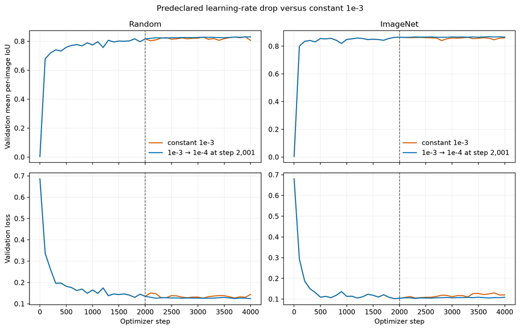

```python
display(Image(filename=ROOT / 'reports/figures/optimization_lr_drop_curves.png'))
```

For ImageNet initialization, the drop raises the best validation IoU from 0.865 to 0.868 and the step-4,000 IoU from 0.860 to 0.866. Its late IoU residual SD falls from 0.0055 to 0.0010, while the step-4,000 validation loss falls from 0.120 to 0.109. For random initialization, the best IoUs are effectively tied (0.830 versus 0.831), but the drop raises the endpoint from 0.806 to 0.830 and reduces residual SD from 0.0075 to 0.0012. The two fresh runs took 25.7 and 25.5 minutes in total, close to the ImageNet reference; the older random reference was slower for a reason not investigated here.

These outcomes support the fixed drop as a more stable common recipe at this horizon. They do not establish a general scheduler advantage: this is one subset/seed, one change point and one terminal rate, evaluated repeatedly on the same validation set. The small ImageNet best-IoU increase is especially vulnerable to validation selection. No test image, test label or test prediction was accessed.

## 11. Does the selected recipe repeat on another training subset?

The fixed-drop recipe is now repeated on the saved n=100 subset generated with subset seed 29. This seed chooses training images; it does not replace the model, data-order or augmentation seeds, which remain fixed. The new random and ImageNet runs use identical training IDs, sample order and D4 transformations, with fresh model initialization under the existing pairing rule. Seed 17 and Seed 29 share 24 of their 100 training IDs. Both repetitions use the same 289-image validation region, so this comparison varies training-image selection rather than all sources of training randomness.

```python
SUBSET_RESULTS = pd.read_csv(
    ROOT / 'reports/optimization_subset_replication_results.csv'
)
subset_columns = {
    'subset_seed': 'subset seed', 'initialization': 'initialization',
    'best_step': 'best step', 'best_validation_iou': 'best IoU',
    'iou_step_4000': 'IoU at 4,000',
    'validation_loss_step_4000': 'loss at 4,000',
    'selected_validation_dice': 'Dice', 'selected_validation_ap': 'AP',
    'iou_trend_per_1000': 'late IoU trend / 1,000',
    'iou_residual_sd': 'late IoU residual SD', 'total_minutes': 'minutes',
}
display(SUBSET_RESULTS[list(subset_columns)].rename(columns=subset_columns).style.format({
    'best IoU': '{:.3f}', 'IoU at 4,000': '{:.3f}', 'loss at 4,000': '{:.3f}',
    'Dice': '{:.3f}', 'AP': '{:.3f}', 'late IoU trend / 1,000': '{:+.4f}',
    'late IoU residual SD': '{:.4f}', 'minutes': '{:.1f}',
}))
```

|  | subset seed | initialization | best step | best IoU | IoU at 4,000 | loss at 4,000 | Dice | AP | late IoU trend / 1,000 | late IoU residual SD | minutes |
| --- | --- | --- | --- | --- | --- | --- | --- | --- | --- | --- | --- |
| 0 | 17 | imagenet | 3700 | 0.868 | 0.866 | 0.109 | 0.926 | 0.969 | +0.0010 | 0.0010 | 25.5 |
| 1 | 17 | random | 4000 | 0.830 | 0.830 | 0.124 | 0.903 | 0.963 | +0.0037 | 0.0012 | 25.7 |
| 2 | 29 | imagenet | 3600 | 0.863 | 0.861 | 0.120 | 0.922 | 0.970 | +0.0030 | 0.0011 | 25.7 |
| 3 | 29 | random | 3600 | 0.831 | 0.827 | 0.128 | 0.903 | 0.965 | +0.0034 | 0.0016 | 25.7 |

```python
PAIRED_SUBSETS = pd.read_csv(
    ROOT / 'reports/optimization_subset_replication_paired.csv'
)
OVERLAP = pd.read_csv(
    ROOT / 'reports/optimization_subset_replication_overlap.csv'
).iloc[0]
display(PAIRED_SUBSETS.style.format({
    'imagenet_minus_random_best_iou': '{:+.3f}',
    'imagenet_minus_random_iou_step_4000': '{:+.3f}',
    'imagenet_minus_random_dice': '{:+.3f}',
    'imagenet_minus_random_ap': '{:+.3f}',
}))
print(f"Shared training IDs: {int(OVERLAP.shared_training_ids)} of 100 per subset")
```

|  | subset_seed | imagenet_minus_random_best_iou | imagenet_minus_random_iou_step_4000 | imagenet_minus_random_dice | imagenet_minus_random_ap |
| --- | --- | --- | --- | --- | --- |
| 0 | 17 | +0.038 | +0.036 | +0.023 | +0.006 |
| 1 | 29 | +0.032 | +0.034 | +0.019 | +0.005 |

```
Shared training IDs: 24 of 100 per subset
```

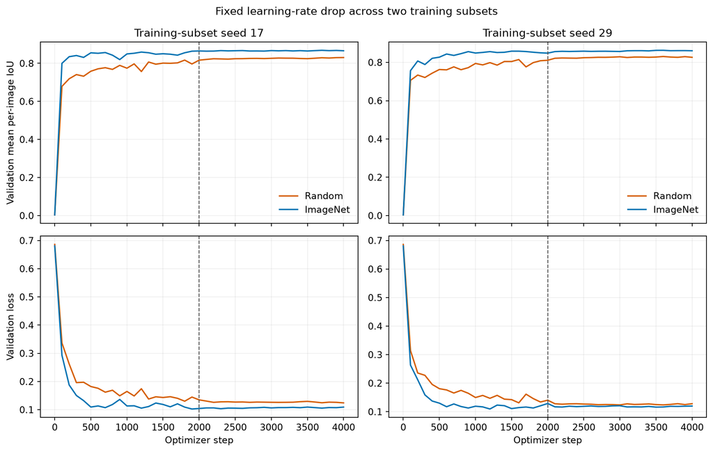

```python
display(Image(filename=ROOT / 'reports/figures/optimization_subset_replication_curves.png'))
```

The selected recipe reaches similar random-initialization maxima on both subsets: 0.830 for Seed 17 and 0.831 for Seed 29. ImageNet reaches 0.868 and 0.863, respectively. The paired ImageNet-minus-random best-IoU advantage is therefore positive in both repetitions (+0.038 and +0.032), as is the fixed step-4,000 difference (+0.036 and +0.034). Dice and AP give the same ordering.

All four late trajectories have positive IoU slopes and low residual SD (0.0010–0.0016). Seed 29 ends at IoU 0.827 for random and 0.861 for ImageNet, close to its selected maxima at step 3,600; validation losses at step 4,000 are 0.128 and 0.120. The two new runs each required 25.7 minutes including evaluation.

This repetition supports the claim that the common recipe trains both initializations stably and that ImageNet initialization retains an advantage when the training-image selection changes. It does **not** isolate a benefit from the drop on Seed 29 because no constant-rate Seed-29 control was run. The two subsets overlap by 24 images, share one validation region and keep all non-subset random sources fixed. Two repetitions cannot establish statistical significance or geographic generalization.

## 12. Conclusion and next decision

The optimization evidence now supports `1e-3` through step 2,000 followed by `1e-4` through step 4,000 as the common working recipe at n=100. Its late behavior is stable on two saved training subsets, and the ImageNet advantage repeats with similar magnitude. The result concerns training-subset sensitivity on one validation region; independent performance remains reserved for the locked test region.

The recommended next limited block is to apply this now-fixed recipe at n=25 and n=500 on the Seed 17 nested subsets for both initializations (four fresh runs). This tests whether the common recipe and pretraining advantage behave similarly at the small and larger label budgets before committing to the full repeated learning-curve series. It is a proposal only; no additional run is started here.